# Vance_week_5_6_assignment

2025-10-19

```r
# IMPORTS


library(dplyr)
```

```r
library(ggplot2)
library(readxl)
library(tidyverse)
library(treemapify)
```

### Call to Action

The current administration has recognized the alarming rates of car thefts. They realize thefts vary by location and time, but the public must be made aware of the crime rates. Our call to action is to inform the general public of crime trends so they can take precautions if they live in an area witnessing an increase in crime.

### Audience

General Public

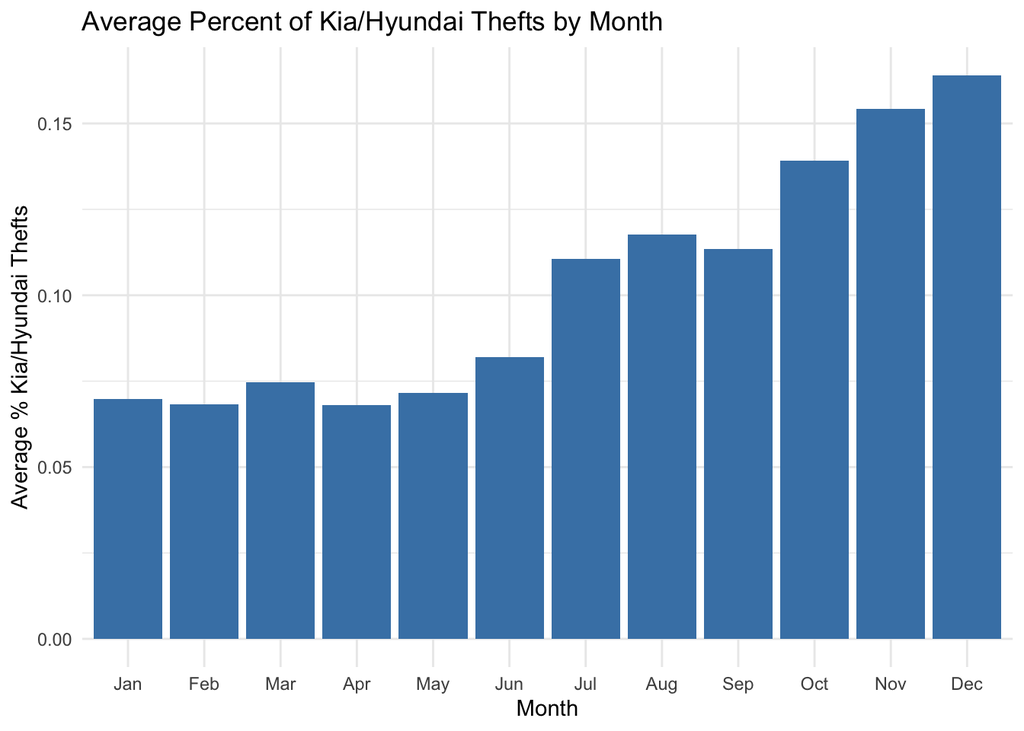

```r
kiaHyundaiThefts <- read.csv("kiaHyundaiThefts.csv")

# print the shape
kiaHyundaiThefts %>%
  group_by(month) %>%
  summarise(across(starts_with("count"), mean),
            percentKiaHyundai = mean(percentKiaHyundai)) %>%
  mutate(month = factor(month, levels = month.abb)) %>%
  ggplot(aes(x = month, y = percentKiaHyundai)) +
  geom_col(fill = "steelblue") +
  labs(title = "Average Percent of Kia/Hyundai Thefts by Month",
       x = "Month", y = "Average % Kia/Hyundai Thefts") +
  theme_minimal()
```

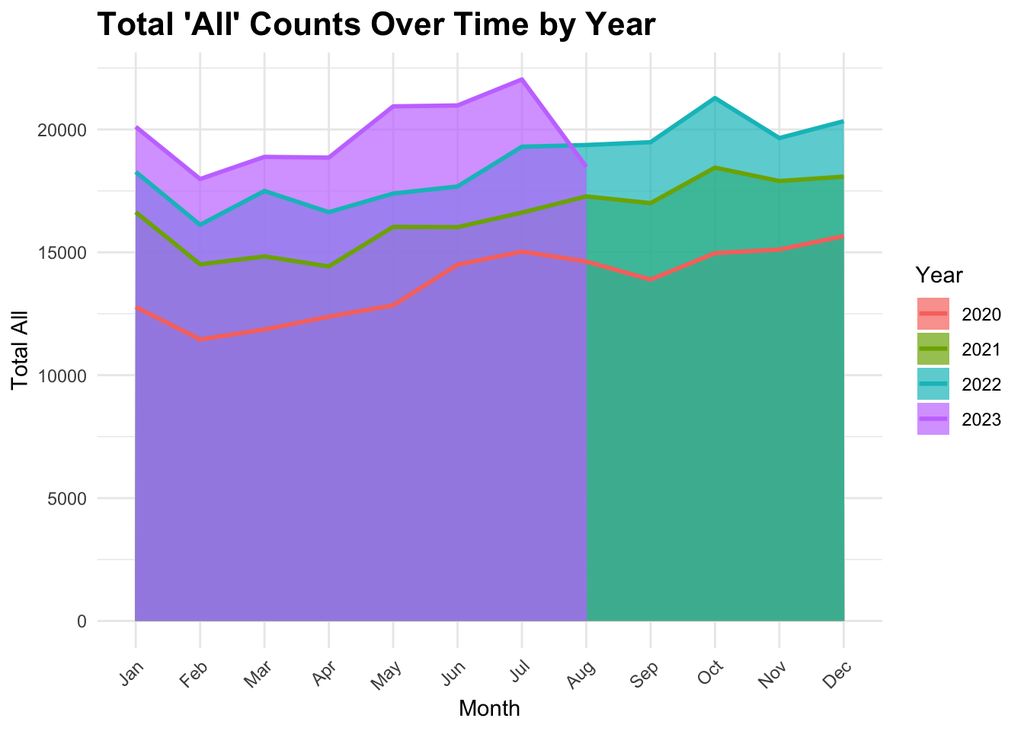

```r
df <- read.csv("tidy_data.csv")
# --- Clean and prepare data ---

df <- df %>%
  # Convert Date to Date type and extract Year and Month
  mutate(
    Date = as.Date(Date),
    Year = year(Date),
    Month = month(Date, label = TRUE, abbr = TRUE)
  )

# --- Summarize total "All" by Year-Month ---
df_summary <- df %>%
  # 2019 is incomplete, so we'll exclude it
  filter(Year != 2019) %>%
  # Aggregate totals
  group_by(Year, Month) %>%
  summarize(TotalAll = sum(All, na.rm = TRUE), .groups = "drop")

# --- Plot area chart ---
ggplot(df_summary, aes(x = Month, y = TotalAll, fill = factor(Year), group = Year)) +
  geom_area(alpha = 0.7, position = "identity") + # Stacked area
  geom_line(aes(color = factor(Year)), linewidth = 1) +
  # Customize labels and theme
  labs(
    title = "Total 'All' Counts Over Time by Year",
    x = "Month",
    y = "Total All",
    fill = "Year",
    color = "Year"
  ) +
  theme_minimal() +
  # Customize theme
  theme(
    plot.title = element_text(size = 16, face = "bold"),
    axis.text.x = element_text(angle = 45, hjust = 1)
  )
```

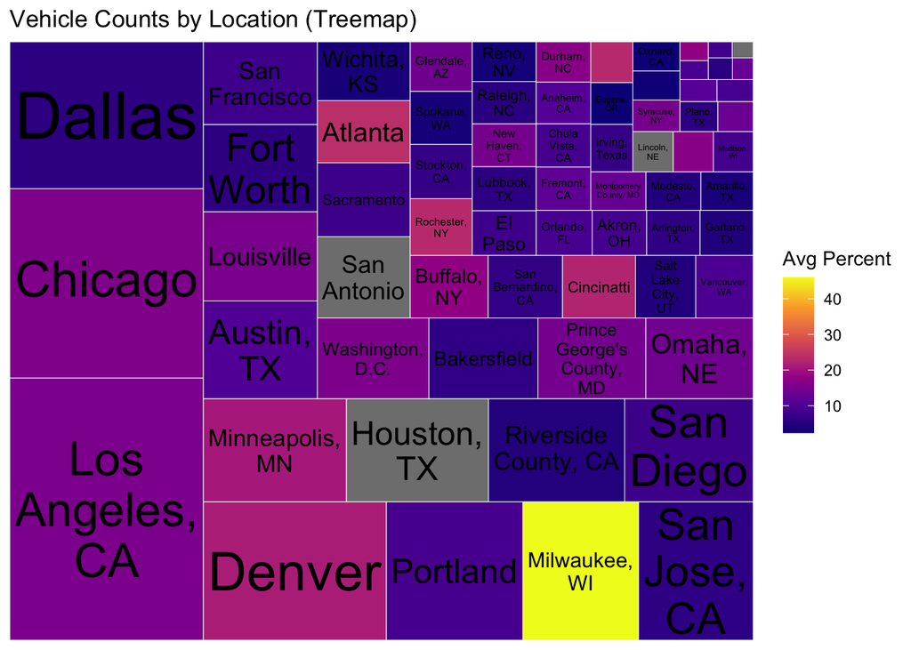

```r
# --- Clean and prepare data ---
df <- df %>%
  mutate(
    Date = as.Date(Date),
    Year = lubridate::year(Date)
  )

# --- Aggregate totals by Location (optional if multiple dates) ---
df_summary <- df %>%
  group_by(Location) %>%
  summarize(
    TotalAll = sum(All, na.rm = TRUE),
    AvgPercent = mean(Percent, na.rm = TRUE)
  )

# --- Treemap ---
ggplot(df_summary, aes(
  area = TotalAll,
  fill = AvgPercent,
  label = Location
)) +
  geom_treemap(color = "white") +
  geom_treemap_text(
    colour = "black",
    place = "centre",
    grow = TRUE,
    reflow = TRUE
  ) +
  scale_fill_viridis_c(option = "plasma") +
  labs(
    title = "Vehicle Counts by Location (Treemap)",
    fill = "Avg Percent"
  ) +
  theme_minimal()
```

```r
df <- read.csv("carTheftsMap.csv", stringsAsFactors = FALSE)

# Convert "-" to NA and columns to numeric
year_cols <- c("countCarThefts2019", "countCarThefts2020", "countCarThefts2021", "countCarThefts2022")
df[year_cols] <- lapply(df[year_cols], function(x) as.numeric(gsub("-", NA, x)))
```

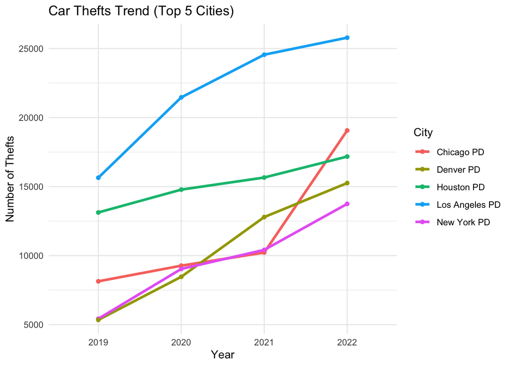

```r
# Gather into long format
df_long <- df %>%
  select(geo_name, all_of(year_cols)) %>%
  pivot_longer(-geo_name, names_to = "Year", values_to = "Thefts") %>%
  mutate(Year = gsub("countCarThefts", "", Year))

# Example: Top 5 cities by 2022 thefts
top_cities <- df %>%
  arrange(desc(countCarThefts2022)) %>%
  slice_head(n = 5) %>%
  pull(geo_name)

ggplot(df_long %>% filter(geo_name %in% top_cities), aes(x = Year, y = Thefts, color = geo_name, group = geo_name)) +
  geom_line(size = 1.2) +
  geom_point() +
  labs(title = "Car Thefts Trend (Top 5 Cities)", x = "Year", y = "Number of Thefts", color = "City") +
  theme_minimal()
```

```r
# Read the data
df <- read_csv("KiaHyundaiMilwaukeeData.csv")
```

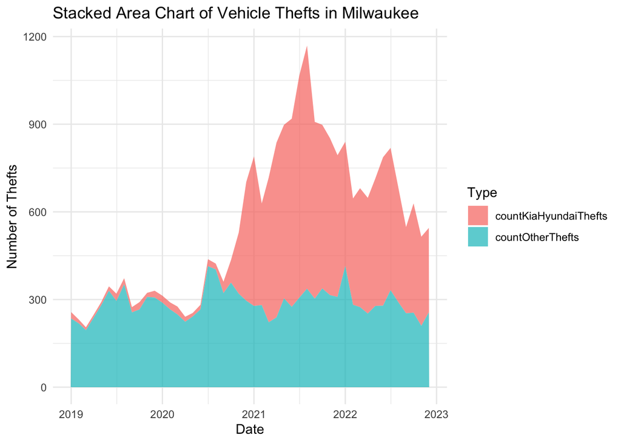

```r
# Create a date column for proper ordering
df <- df %>%
  mutate(date = as.Date(paste(year, month, "01", sep = "-"), format = "%Y-%b-%d"))

# Reshape to long format for stacking
df_long <- df %>%
  select(date, countKiaHyundaiThefts, countOtherThefts) %>%
  pivot_longer(cols = c(countKiaHyundaiThefts, countOtherThefts),
               names_to = "Type", values_to = "Count")

# Plot stacked area chart
ggplot(df_long, aes(x = date, y = Count, fill = Type)) +
  geom_area(alpha = 0.7) +
  labs(title = "Stacked Area Chart of Vehicle Thefts in Milwaukee",
       x = "Date", y = "Number of Thefts", fill = "Type") +
  theme_minimal()
```

We examined the top cities and saw similar trends. Despite being in different regions, Chicago, Denver, Houston, Los Angeles, and New York all saw increases in car thefts from 2019 to 2022.

Additionally, we examined Hyundai and Kia thefts across the country. Most areas only saw these cars make up a small percentage of total car thefts. However, in Milwaukee, these two brands made up almost half of all car thefts.